# Econometria espacial com R - Aula 02

Unicamp, julho de 2017

Raphael Saldanha, Eduardo Almeida

# Análise Exploratória de Dados Espaciais

## Leitura do shapefile

Para a leitura de arquivos **shapefile** no R, precisamos usar alguns pacotes. Após a instalação dos pacotes, use os seguintes comandos.

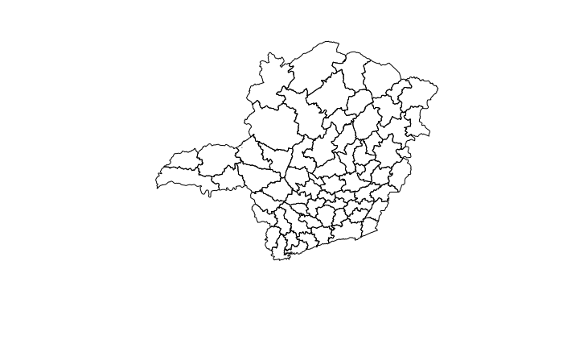

```r
fp_mg.shp <- readOGR("data", "FP_MG", encoding = "ISO-8859-1")
fp_mg.shp <- readOGR("data", "FP_MG", encoding = "ISO-8859-1")
plot(fp_mg.shp)
```

## Atributos do shapefile

Podemos ver a tabela de atributos do shapefile com desta forma.

|  | CODMIC | NOMMIC | Q | AC | AP | K | R | RP | RNP | DRNP | F | AREA | ESCTOT | POPTOT | LP | ACP | KP | ETOTP | DRNPP | FP | RNPP | RPP | R_P | QP | X_COORD | Y_COORD | CMICRO | VP | VPP | … |
| --- | --- | --- | --- | --- | --- | --- | --- | --- | --- | --- | --- | --- | --- | --- | --- | --- | --- | --- | --- | --- | --- | --- | --- | --- | --- | --- | --- | --- | --- | --- |
| 0 | 41 | Aimorés | 134310 | 60132 | 60132 | 1833 | 363 | 155 | 208 | 25 | 84 | 8354.1 | 347 | 152658 | 0.111 | 0.394 | 0.012 | 0.00227 | 0.00016 | 0.000550 | 0.001363 | 0.001015 | 0.002378 | 0.879810 | -41.38876 | -19.53116 | 31041 | 78349 | 0.513232 | … |
| 1 | 49 | Alfenas | 564476 | 113253 | 113253 | 7203 | 312 | 273 | 39 | 8 | 1 | 4998.9 | 229 | 179366 | 0.111 | 0.631 | 0.040 | 0.00128 | 0.00004 | 0.000006 | 0.000217 | 0.001522 | 0.001739 | 3.147062 | -46.01852 | -21.37551 | 31049 | 216064 | 1.204598 | … |
| 2 | 14 | Almenara | 84631 | 20737 | 20737 | 783 | 383 | 150 | 233 | 15 | 1 | 15504.5 | 384 | 213342 | 0.047 | 0.097 | 0.004 | 0.00180 | 0.00007 | 0.000005 | 0.001092 | 0.000703 | 0.001795 | 0.396692 | -40.65978 | -16.35385 | 31014 | 40164 | 0.188261 | … |
| 3 | 55 | Andrelândia | 59164 | 27764 | 27764 | 1154 | 264 | 200 | 64 | 13 | 227 | 5047.3 | 191 | 70783 | 0.037 | 0.392 | 0.016 | 0.00270 | 0.00018 | 0.003207 | 0.000904 | 0.002826 | 0.003730 | 0.835850 | -44.44562 | -21.95045 | 31055 | 42360 | 0.598449 | … |
| 4 | 12 | Araçuaí | 159897 | 36779 | 36779 | 552 | 315 | 162 | 153 | 15 | 1 | 10299.4 | 327 | 143468 | 0.143 | 0.256 | 0.004 | 0.00228 | 0.00010 | 0.000007 | 0.001066 | 0.001129 | 0.002196 | 1.114513 | -41.87023 | -17.00645 | 31012 | 28864 | 0.201188 | … |
| 5 | 23 | Araxá | 495102 | 160580 | 160643 | 7582 | 645 | 564 | 81 | 6 | 327 | 14145.6 | 182 | 158275 | 0.043 | 1.015 | 0.048 | 0.00115 | 0.00004 | 0.002066 | 0.000512 | 0.003563 | 0.004075 | 3.128112 | -46.95948 | -19.59779 | 31023 | 197010 | 1.244732 | … |
| 6 | 59 | Barbacena | 112632 | 34487 | 34508 | 2208 | 226 | 155 | 71 | 21 | 90 | 3370.0 | 239 | 204119 | 0.027 | 0.169 | 0.011 | 0.00117 | 0.00010 | 0.000441 | 0.000348 | 0.000759 | 0.001107 | 0.551796 | -43.75469 | -21.22165 | 31059 | 54692 | 0.267942 | … |
| 7 | 30 | Belo Horizonte | 105895 | 16925 | 16959 | 3048 | 377 | 371 | 5 | 1 | 587 | 5826.9 | 1531 | 3622692 | 0.002 | 0.005 | 0.001 | 0.00042 | 0.00000 | 0.000162 | 0.000001 | 0.000102 | 0.000104 | 0.029231 | -44.03464 | -19.90697 | 31030 | 89076 | 0.024588 | … |
| 8 | 9 | Bocaiúva | 189720 | 16802 | 16802 | 1261 | 132 | 116 | 16 | 2 | 113 | 7812.3 | 117 | 58277 | 0.055 | 0.288 | 0.022 | 0.00201 | 0.00003 | 0.001939 | 0.000275 | 0.001990 | 0.002265 | 3.255487 | -43.78045 | -17.38823 | 31009 | 20282 | 0.348028 | … |
| 9 | 26 | Bom Despacho | 1091182 | 51871 | 51871 | 4195 | 371 | 325 | 46 | 6 | 48 | 7515.5 | 165 | 124687 | 0.025 | 0.416 | 0.034 | 0.00132 | 0.00005 | 0.000385 | 0.000369 | 0.002607 | 0.002975 | 8.751369 | -45.44562 | -19.69013 | 31026 | 128541 | 1.030909 | … |

[output cut: 56 more lines]

## Mapa

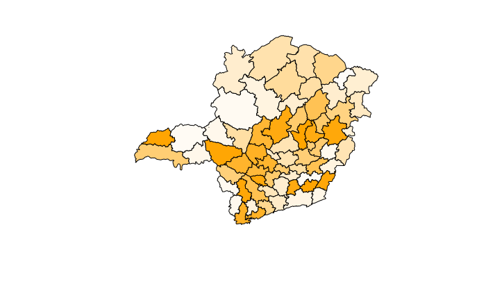

### Sua vez

Faça um mapa com a variável AC com a cor vermelha.

## Matriz de vizinhos espaciais

Para a criação de matrizes de vizinhos espaciais, iremos utilizar o pacote `spdep`.

### Matriz queen e rook

```r
# Matriz queen
w1 <- nb2listw(poly2nb(fp_mg.shp, queen = TRUE))
summary(w1)

# Matrix queen padronizada na linha
w1.w <- nb2listw(poly2nb(fp_mg.shp, queen=TRUE), style="W")
summary(w1.w)

# Matriz rook
w2 <- nb2listw(poly2nb(fp_mg.shp, queen = FALSE))
summary(w2)

# Matriz rook padronizada globalmente
w2.c <- nb2listw(poly2nb(fp_mg.shp, queen = FALSE), style = "C")
summary(w2.c)
```

### Distância inversa

```r
coords <- coordinates(fp_mg.shp)
nb <- dnearneigh(coords, 0, 1000)
dlist <- nbdists(nb, coords)
dlist <- lapply(dlist, function(x) 1/x)
w3 <- nb2listw(nb, glist=dlist)
summary(w3)

# Distância inversa padronizada pelo número de vizinhos
w3.u <- nb2listw(nb, glist=dlist, style="U")
summary(w3.u)
```

Para ver mais opções, veja a ajuda deste comando: `?nb2listw`

### Matriz de k-vizinhos espaciais

A escolha do número ideal de $k$ vizinhos será realizada testando-se vários $k$ e utilizando-se o que retornou o maior valor para a estatística $I$ de Moran significativo.

```r
# Número de permutações
per <- 999

# Número máximo de k vizinhos testados
kv <- 20

# Nome dos registros
IDs <- row.names(fp_mg.shp@data)

# Criação da tabela que irá receber a estatística I de Moran e significância para cada k testado
res.pesos <- data.frame(k=numeric(),i=numeric(),valorp=numeric())

# Início do loop
for(k in 1:kv)
{
  # Armazenando número k atual
  res.pesos[k,1] <- k
  # Calculando o I e significância para o k atual
  moran.k <- moran.mc(fp_mg.shp@data$Q,
                      listw=nb2listw(knn2nb(
                      knearneigh(coords, k=k),
                      row.names=IDs),style="B"),
                      nsim=per)
  # Armazenando o valor I para o k atual
  res.pesos[k,2] <- moran.k$statistic
  # Armazenando o p-value para o k atual
  res.pesos[k,3] <- moran.k$p.value
}

# Ver a tabela de k vizinhos, I de Moran e significância
res.pesos

# Sendo todos significativos, iremos usar o k que retornou o maior valor I
maxi <- which.max(res.pesos[,2])

# Criação da matriz usando o k escolhido
w5 <- nb2listw(knn2nb(knearneigh(coords, k=maxi),row.names=IDs),style="B")
summary(w5)
```

## Autocorrelação espacial global

### I de Moran

```r
moran.test(fp_mg.shp@data$Q, listw = w5)
moran.mc(fp_mg.shp@data$Q, listw = w5, nsim = 999)
```

### C de Geary

```r
geary.test(fp_mg.shp@data$Q, listw = w5)
```

### G de Getis-Ord

```r
globalG.test(fp_mg.shp@data$Q, listw = w5)
```

## Autocorrelação espacial local

### G de Gettis-Ords

```r
lg1 <- localG(fp_mg.shp@data$Q, listw = w5)
summary(lg1)
```

### I de Moran

```r
# Cálculo
lm1 <- localmoran(fp_mg.shp@data$Q, listw = w5)
summary(lm1)

# Quantos são significativos?
table(lm1<0.05)
```

## Diagrama de dispersão de Moran

```r
moran.plot(fp_mg.shp@data$Q, listw = w5)
```

### Sua vez

Calcule o I de Moran local usando a matriz de vizinhança `w1` para a variável `AC`e verifique quantas regiões são significativas. Depois, faça o diagrama de dispersão.

## LISA map

O R não tem uma função pronta para criar um mapa LISA, então nós criamos abaixo nossa própria função: `lisaplot`. Depois de declarada, uma função pode ser usada repetidamente variando seus argumentos.

Rode o código abaixo.

```r
lisaplot <- function(shapefile, values, listw, pval = 0.05){
  require(spdep)

  svalues <- scale(values)
  lag_svalues <- spdep::lag.listw(listw, svalues)
  locm <- spdep::localmoran(values, listw)
  sig <- rep(5, length(values))

  sig[(svalues >= 0 & lag_svalues >= 0) & (locm[,5] <= pval)] <- 1
  sig[(svalues <= 0 & lag_svalues <= 0) & (locm[,5] <= pval)] <- 2
  sig[(svalues >= 0 & lag_svalues <= 0) & (locm[,5] <= pval)] <- 3
  sig[(svalues >= 0 & lag_svalues <= 0) & (locm[,5] <= pval)] <- 4
  sig[(svalues <= 0 & lag_svalues >= 0) & (locm[,5] <= pval)] <- 5

  breaks <- seq(1, 5, 1)
  labels <- c("Alto-Alto", "Baixo-Baixo", "Alto-Baixo", "Baixo-Alto", "N. Sig.")
  np <- findInterval(sig, breaks)
  colors <- c("red", "blue", "lightpink", "skyblue2", "white")
  plot(shapefile, col = colors[np])  #colors[np] manually sets the color for each county
  mtext("LISA", cex = 1.5, side = 3, line = 1)
  legend("topleft", legend = labels, fill = colors, bty = "n")
}

lisaplot(fp_mg.shp, fp_mg.shp@data$R, w5)
```

E o LISA para a variável `TEMP`.

```r
lisaplot(fp_mg.shp, fp_mg.shp@data$TEMP, w5)
```

### Sua vez

Faça o LISA para a variável `AP` com a matriz `w1`.